# disseration

30119304

2025-06-05

```r
# Load the dataset
df <- read_csv("C:/Users/dell/OneDrive - University of South Wales/Desktop/DESERTATION/TATA Online Retail Dataset/Online Retail Data Set.csv")

# View structure
str(df)
```

```
## spc_tbl_ [541,909 × 8] (S3: spec_tbl_df/tbl_df/tbl/data.frame)
##  $ InvoiceNo  : chr [1:541909] "536365" "536365" "536365" "536365" ...
##  $ StockCode  : chr [1:541909] "85123A" "71053" "84406B" "84029G" ...
##  $ Description: chr [1:541909] "WHITE HANGING HEART T-LIGHT HOLDER" "WHITE METAL LANTERN" "CREAM CUPID HEARTS COAT HANGER" "KNITTED UNION FLAG HOT WATER BOTTLE" ...
##  $ Quantity   : num [1:541909] 6 6 8 6 6 2 6 6 6 32 ...
##  $ InvoiceDate: chr [1:541909] "01-12-2010 08:26" "01-12-2010 08:26" "01-12-2010 08:26" "01-12-2010 08:26" ...
##  $ UnitPrice  : num [1:541909] 2.55 3.39 2.75 3.39 3.39 7.65 4.25 1.85 1.85 1.69 ...
##  $ CustomerID : num [1:541909] 17850 17850 17850 17850 17850 ...
##  $ Country    : chr [1:541909] "United Kingdom" "United Kingdom" "United Kingdom" "United Kingdom" ...
##  - attr(*, "spec")=
##   .. cols(
##   ..   InvoiceNo = col_character(),
##   ..   StockCode = col_character(),
##   ..   Description = col_character(),
##   ..   Quantity = col_double(),
##   ..   InvoiceDate = col_character(),
##   ..   UnitPrice = col_double(),
##   ..   CustomerID = col_double(),
##   ..   Country = col_character()
##   .. )
##  - attr(*, "problems")=<externalptr>
```

```r
# View first few rows
head(df)
```

```
## # A tibble: 6 × 8
##   InvoiceNo StockCode Description      Quantity InvoiceDate UnitPrice CustomerID
##   <chr>     <chr>     <chr>               <dbl> <chr>           <dbl>      <dbl>
## 1 536365    85123A    WHITE HANGING H…        6 01-12-2010…      2.55      17850
## 2 536365    71053     WHITE METAL LAN…        6 01-12-2010…      3.39      17850
## 3 536365    84406B    CREAM CUPID HEA…        8 01-12-2010…      2.75      17850
## 4 536365    84029G    KNITTED UNION F…        6 01-12-2010…      3.39      17850
## 5 536365    84029E    RED WOOLLY HOTT…        6 01-12-2010…      3.39      17850
## 6 536365    22752     SET 7 BABUSHKA …        2 01-12-2010…      7.65      17850
## # ℹ 1 more variable: Country <chr>
```

```r
# Count missing values per column
colSums(is.na(df))
```

```
##   InvoiceNo   StockCode Description    Quantity InvoiceDate   UnitPrice
##           0           0        1454           0           0           0
##  CustomerID     Country
##      135080           0
```

```r
# Remove rows with missing CustomerID or Description
df_clean <- df %>%
  filter(!is.na(CustomerID), !is.na(Description))

# Check again
colSums(is.na(df_clean))
```

```
##   InvoiceNo   StockCode Description    Quantity InvoiceDate   UnitPrice
##           0           0           0           0           0           0
##  CustomerID     Country
##           0           0
```

```r
library(readr)
library(dplyr)
library(lubridate)

# Step 1: Load dataset with InvoiceDate as character
df <- read_csv("C:/Users/dell/OneDrive - University of South Wales/Desktop/DESERTATION/TATA Online Retail Dataset/Online Retail Data Set.csv",
               col_types = cols(InvoiceDate = col_character()))

# Step 2: Remove rows with missing CustomerID or Description
df <- df %>%
  filter(!is.na(CustomerID), !is.na(Description))

# ✅ Step 3: Check for negative values (optional but informative)
cat("Negative Quantities: ", sum(df$Quantity < 0), "\n")
```

```
## Negative Quantities:  8905
```

```r
cat("Negative Prices: ", sum(df$UnitPrice < 0), "\n")
```

```
## Negative Prices:  0
```

```r
# Step 4: Remove negative Quantity and UnitPrice values
df <- df %>%
  filter(Quantity > 0, UnitPrice > 0)

# Step 5: Parse InvoiceDate to POSIXct
df <- df %>%
  mutate(InvoiceDate = parse_date_time(InvoiceDate, orders = "dmy HM"))

# Step 6: Add TotalPrice column
df <- df %>%
  mutate(TotalPrice = Quantity * UnitPrice)

# Step 7: Remove duplicate rows
df <- df %>%
  distinct()

# Step 8: Check structure and preview
str(df)
```

```
## tibble [392,692 × 9] (S3: tbl_df/tbl/data.frame)
##  $ InvoiceNo  : chr [1:392692] "536365" "536365" "536365" "536365" ...
##  $ StockCode  : chr [1:392692] "85123A" "71053" "84406B" "84029G" ...
##  $ Description: chr [1:392692] "WHITE HANGING HEART T-LIGHT HOLDER" "WHITE METAL LANTERN" "CREAM CUPID HEARTS COAT HANGER" "KNITTED UNION FLAG HOT WATER BOTTLE" ...
##  $ Quantity   : num [1:392692] 6 6 8 6 6 2 6 6 6 32 ...
##  $ InvoiceDate: POSIXct[1:392692], format: "2010-12-01 08:26:00" "2010-12-01 08:26:00" ...
##  $ UnitPrice  : num [1:392692] 2.55 3.39 2.75 3.39 3.39 7.65 4.25 1.85 1.85 1.69 ...
##  $ CustomerID : num [1:392692] 17850 17850 17850 17850 17850 ...
##  $ Country    : chr [1:392692] "United Kingdom" "United Kingdom" "United Kingdom" "United Kingdom" ...
##  $ TotalPrice : num [1:392692] 15.3 20.3 22 20.3 20.3 ...
```

```r
head(df)
```

```
## # A tibble: 6 × 9
##   InvoiceNo StockCode Description         Quantity InvoiceDate         UnitPrice
##   <chr>     <chr>     <chr>                  <dbl> <dttm>                  <dbl>
## 1 536365    85123A    WHITE HANGING HEAR…        6 2010-12-01 08:26:00      2.55
## 2 536365    71053     WHITE METAL LANTERN        6 2010-12-01 08:26:00      3.39
## 3 536365    84406B    CREAM CUPID HEARTS…        8 2010-12-01 08:26:00      2.75
## 4 536365    84029G    KNITTED UNION FLAG…        6 2010-12-01 08:26:00      3.39
## 5 536365    84029E    RED WOOLLY HOTTIE …        6 2010-12-01 08:26:00      3.39
## 6 536365    22752     SET 7 BABUSHKA NES…        2 2010-12-01 08:26:00      7.65
## # ℹ 3 more variables: CustomerID <dbl>, Country <chr>, TotalPrice <dbl>
```

```r
library(stringr)
library(dplyr)

# Fix encoding first
df$Description <- df$Description %>%
  iconv(from = "latin1", to = "UTF-8", sub = "") %>%  # removes problematic chars
  tolower() %>%
  str_trim() %>%
  str_replace_all("[[:punct:]]", "")  # optional punctuation removal

#Identify returns (InvoiceNo starting with 'C')
returns_df <- df %>%
  filter(str_starts(InvoiceNo, "C"))

# If you want to exclude returns from main dataset
df <- df %>%
  filter(!str_starts(InvoiceNo, "C"))
# View cleaned product descriptions
head(df$Description, 10)
```

```
##  [1] "white hanging heart tlight holder"   "white metal lantern"
##  [3] "cream cupid hearts coat hanger"      "knitted union flag hot water bottle"
##  [5] "red woolly hottie white heart"       "set 7 babushka nesting boxes"
##  [7] "glass star frosted tlight holder"    "hand warmer union jack"
##  [9] "hand warmer red polka dot"           "assorted colour bird ornament"
```

```r
# Confirm number of returns removed
nrow(returns_df)
```

```
## [1] 0
```

```r
# Confirm number of remaining rows
nrow(df)
```

```
## [1] 392692
```

```r
# Full clean again (if needed)
df_clean <- read_csv("C:/Users/dell/OneDrive - University of South Wales/Desktop/DESERTATION/TATA Online Retail Dataset/Online Retail Data Set.csv", col_types = cols(InvoiceDate = col_character())) %>%
  filter(!is.na(CustomerID), !is.na(Description)) %>%
  filter(Quantity > 0, UnitPrice > 0) %>%
  mutate(
    InvoiceDate = parse_date_time(InvoiceDate, orders = "dmy HM"),
    TotalPrice = Quantity * UnitPrice,
    Description = iconv(Description, from = "latin1", to = "UTF-8", sub = "") %>%
                  tolower() %>%
                  str_trim() %>%
                  str_replace_all("[[:punct:]]", "")
  ) %>%
  filter(!str_starts(InvoiceNo, "C")) %>%
  distinct()
str(df_clean)
```

```
## tibble [392,692 × 9] (S3: tbl_df/tbl/data.frame)
##  $ InvoiceNo  : chr [1:392692] "536365" "536365" "536365" "536365" ...
##  $ StockCode  : chr [1:392692] "85123A" "71053" "84406B" "84029G" ...
##  $ Description: chr [1:392692] "white hanging heart tlight holder" "white metal lantern" "cream cupid hearts coat hanger" "knitted union flag hot water bottle" ...
##  $ Quantity   : num [1:392692] 6 6 8 6 6 2 6 6 6 32 ...
##  $ InvoiceDate: POSIXct[1:392692], format: "2010-12-01 08:26:00" "2010-12-01 08:26:00" ...
##  $ UnitPrice  : num [1:392692] 2.55 3.39 2.75 3.39 3.39 7.65 4.25 1.85 1.85 1.69 ...
##  $ CustomerID : num [1:392692] 17850 17850 17850 17850 17850 ...
##  $ Country    : chr [1:392692] "United Kingdom" "United Kingdom" "United Kingdom" "United Kingdom" ...
##  $ TotalPrice : num [1:392692] 15.3 20.3 22 20.3 20.3 ...
```

```r
summary(df_clean$InvoiceDate)
```

```
##                       Min.                    1st Qu.
## "2010-12-01 08:26:00.0000" "2011-04-07 11:12:00.0000"
##                     Median                       Mean
## "2011-07-31 12:02:00.0000" "2011-07-10 19:13:07.7718"
##                    3rd Qu.                       Max.
## "2011-10-20 12:53:00.0000" "2011-12-09 12:50:00.0000"
```

```r
df_clean <- df_clean %>%
  mutate(TotalPrice = Quantity * UnitPrice)
```

```r
glimpse(df)
```

```
## Rows: 392,692
## Columns: 9
## $ InvoiceNo   <chr> "536365", "536365", "536365", "536365", "536365", "536365"…
## $ StockCode   <chr> "85123A", "71053", "84406B", "84029G", "84029E", "22752", …
## $ Description <chr> "white hanging heart tlight holder", "white metal lantern"…
## $ Quantity    <dbl> 6, 6, 8, 6, 6, 2, 6, 6, 6, 32, 6, 6, 8, 6, 6, 3, 2, 3, 3, …
## $ InvoiceDate <dttm> 2010-12-01 08:26:00, 2010-12-01 08:26:00, 2010-12-01 08:2…
## $ UnitPrice   <dbl> 2.55, 3.39, 2.75, 3.39, 3.39, 7.65, 4.25, 1.85, 1.85, 1.69…
## $ CustomerID  <dbl> 17850, 17850, 17850, 17850, 17850, 17850, 17850, 17850, 17…
## $ Country     <chr> "United Kingdom", "United Kingdom", "United Kingdom", "Uni…
## $ TotalPrice  <dbl> 15.30, 20.34, 22.00, 20.34, 20.34, 15.30, 25.50, 11.10, 11…
```

```r
summary(df$TotalPrice)
```

```
##      Min.   1st Qu.    Median      Mean   3rd Qu.      Max.
##      0.00      4.95     12.45     22.63     19.80 168469.60
```

#EDA

```r
knitr::opts_chunk$set(echo = TRUE, warning = FALSE, message = FALSE)
library(dplyr)
library(ggplot2)
library(lubridate)
library(scales)
```

```r
##Analyze Sales Patterns

### 5.1 Top-Selling Products by Revenue
# Load necessary library
library(dplyr)
library(ggplot2)

# Group by product Description and calculate total revenue
top_products <- df %>%
  group_by(Description) %>%
  summarise(TotalRevenue = sum(TotalPrice, na.rm = TRUE)) %>%
  arrange(desc(TotalRevenue)) %>%
  slice_head(n = 10)  # Top 10 products

# View top products
print(top_products)
```

```
## # A tibble: 10 × 2
##    Description                       TotalRevenue
##    <chr>                                    <dbl>
##  1 paper craft  little birdie             168470.
##  2 regency cakestand 3 tier               142265.
##  3 white hanging heart tlight holder      100392.
##  4 jumbo bag red retrospot                 85041.
##  5 medium ceramic top storage jar          81417.
##  6 postage                                 77804.
##  7 party bunting                           68785.
##  8 assorted colour bird ornament           56413.
##  9 manual                                  53420.
## 10 rabbit night light                      51251.
```

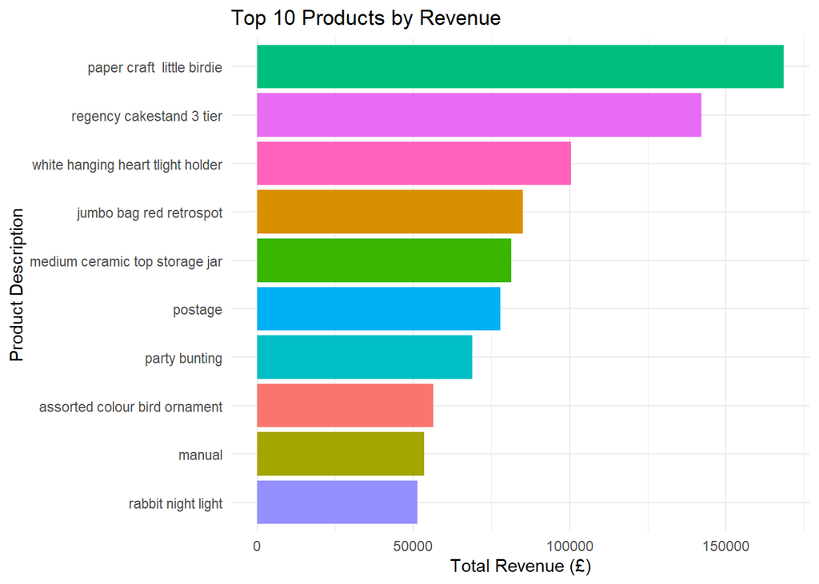

```r
# Plot top-selling products
ggplot(top_products, aes(x = reorder(Description, TotalRevenue), y = TotalRevenue, fill = Description)) +
  geom_bar(stat = "identity", show.legend = FALSE) +
  coord_flip() +
  labs(title = "Top 10 Products by Revenue",
       x = "Product Description",
       y = "Total Revenue (£)") +
  theme_minimal()
```

#Total Sales Per Month/Year

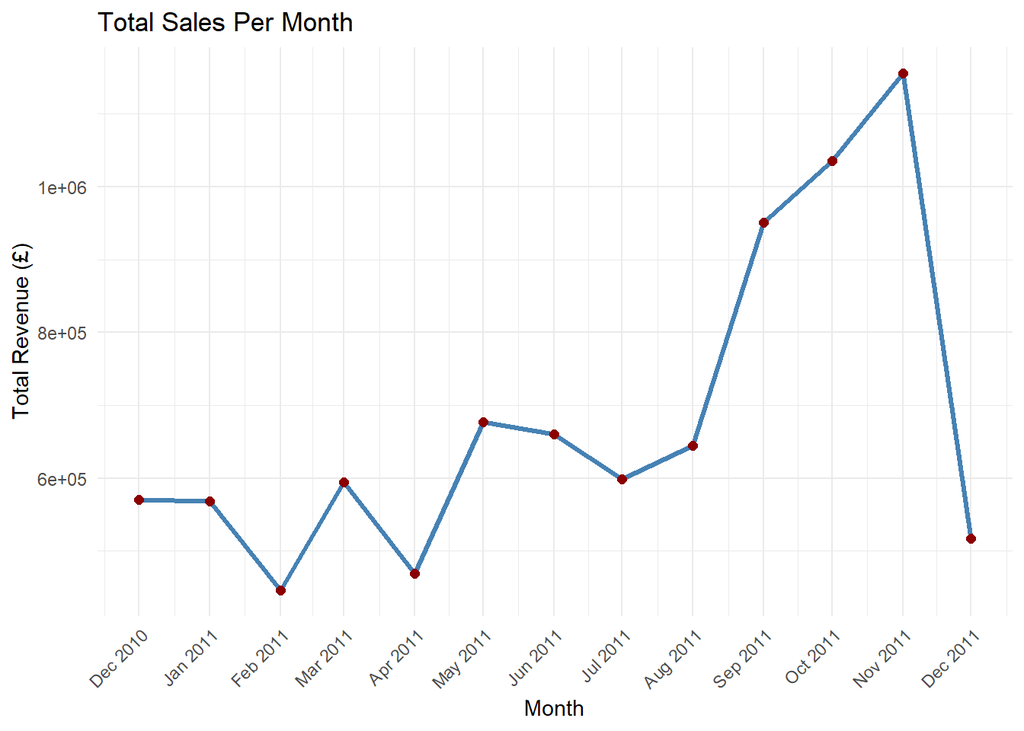

```r
library(dplyr)
library(ggplot2)
library(lubridate)

# Create a Year-Month column as Date (not POSIXct)
df_monthly <- df %>%
  mutate(YearMonth = as.Date(floor_date(InvoiceDate, "month"))) %>%
  group_by(YearMonth) %>%
  summarise(MonthlyRevenue = sum(TotalPrice, na.rm = TRUE)) %>%
  arrange(YearMonth)

# Plot total sales per month
ggplot(df_monthly, aes(x = YearMonth, y = MonthlyRevenue)) +
  geom_line(color = "steelblue", size = 1.2) +
  geom_point(color = "darkred", size = 2) +
  labs(title = "Total Sales Per Month",
       x = "Month",
       y = "Total Revenue (£)") +
  scale_x_date(date_labels = "%b %Y", date_breaks = "1 month") +
  theme_minimal() +
  theme(axis.text.x = element_text(angle = 45, hjust = 1))
```

###Number of Transactions Per Day/Week/Month

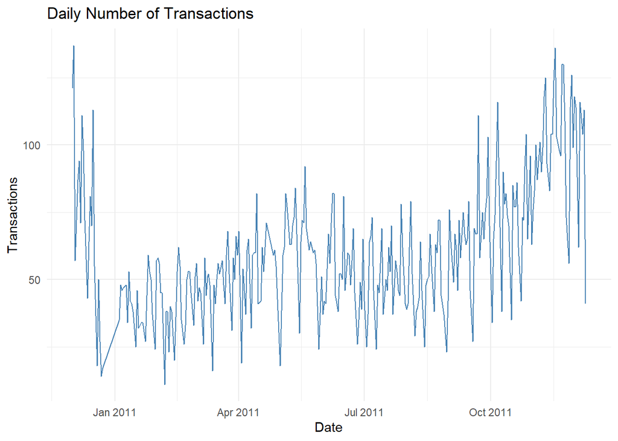

```r
library(dplyr)
library(ggplot2)
library(lubridate)

# Daily Transactions
transactions_daily <- df %>%
  mutate(Date = as.Date(InvoiceDate)) %>%
  group_by(Date) %>%
  summarise(Transactions = n_distinct(InvoiceNo))

# Plot Daily
ggplot(transactions_daily, aes(x = Date, y = Transactions)) +
  geom_line(color = "steelblue") +
  labs(title = "Daily Number of Transactions",
       x = "Date",
       y = "Transactions") +
  theme_minimal()
```

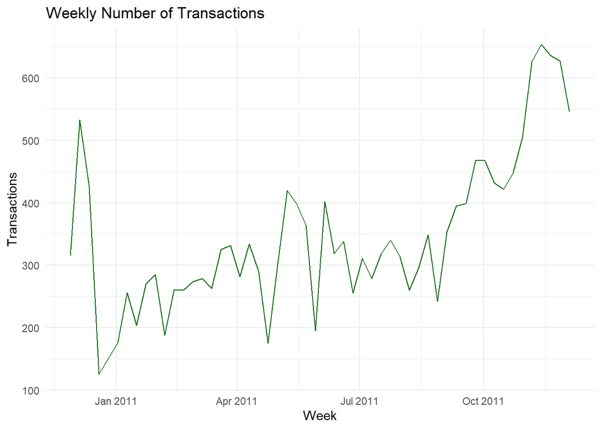

```r
# Weekly Transactions
transactions_weekly <- df %>%
  mutate(Week = floor_date(InvoiceDate, "week")) %>%
  group_by(Week) %>%
  summarise(Transactions = n_distinct(InvoiceNo))

# Plot Weekly
ggplot(transactions_weekly, aes(x = Week, y = Transactions)) +
  geom_line(color = "darkgreen") +
  labs(title = "Weekly Number of Transactions",
       x = "Week",
       y = "Transactions") +
  theme_minimal()
```

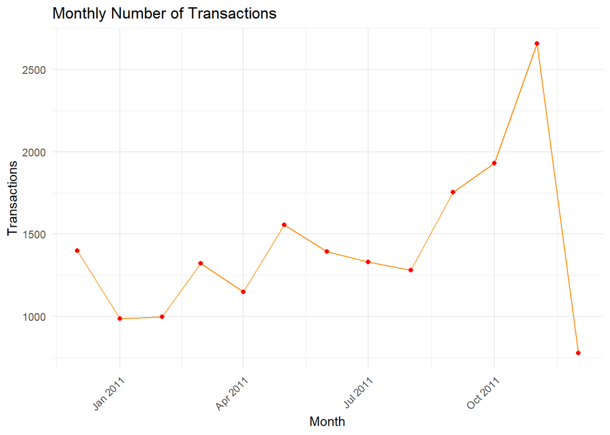

```r
# Monthly Transactions
transactions_monthly <- df %>%
  mutate(Month = floor_date(InvoiceDate, "month")) %>%
  group_by(Month) %>%
  summarise(Transactions = n_distinct(InvoiceNo))

# Plot Monthly
ggplot(transactions_monthly, aes(x = Month, y = Transactions)) +
  geom_line(color = "darkorange") +
  geom_point(color = "red") +
  labs(title = "Monthly Number of Transactions",
       x = "Month",
       y = "Transactions") +
  theme_minimal() +
  theme(axis.text.x = element_text(angle = 45, hjust = 1))
```

#Basket Size Per Month (Trend Over Time)

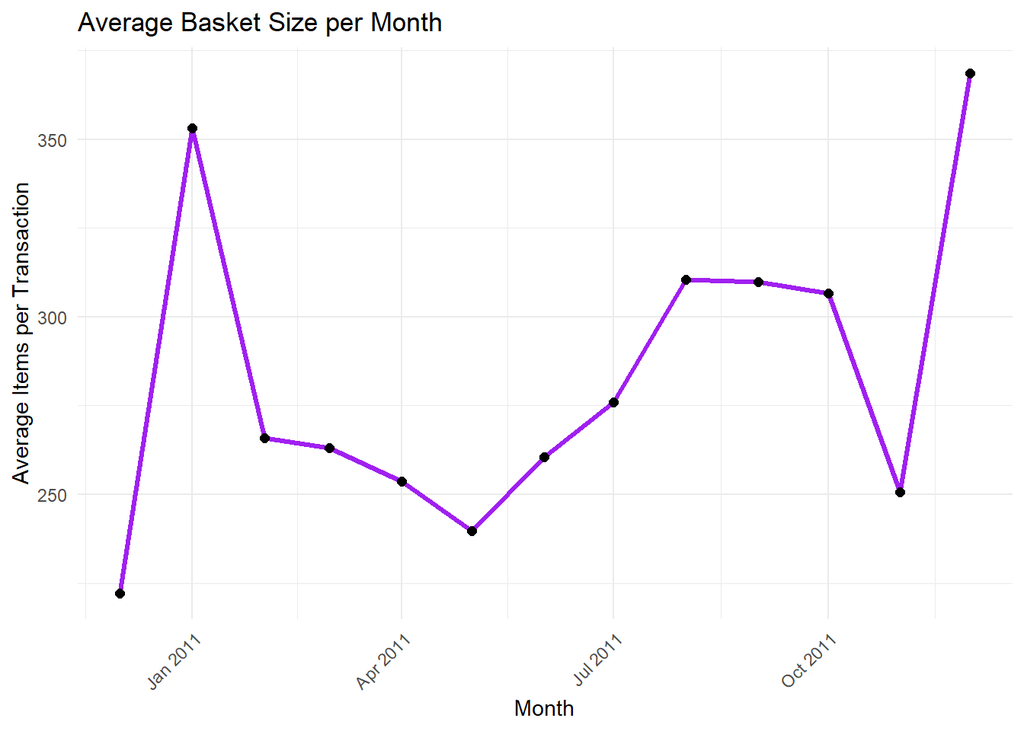

```r
library(dplyr)
library(ggplot2)
library(lubridate)

# Calculate average basket size per month
basket_monthly <- df %>%
  mutate(Month = floor_date(InvoiceDate, "month")) %>%
  group_by(Month) %>%
  summarise(
    TotalQuantity = sum(Quantity),
    Transactions = n_distinct(InvoiceNo),
    AvgBasketSize = TotalQuantity / Transactions
  )

# Plot average basket size trend
ggplot(basket_monthly, aes(x = Month, y = AvgBasketSize)) +
  geom_line(color = "purple", size = 1.2) +
  geom_point(color = "black", size = 2) +
  labs(title = "Average Basket Size per Month",
       x = "Month",
       y = "Average Items per Transaction") +
  theme_minimal() +
  theme(axis.text.x = element_text(angle = 45, hjust = 1))
```

###Top 10 Frequently Bought Products

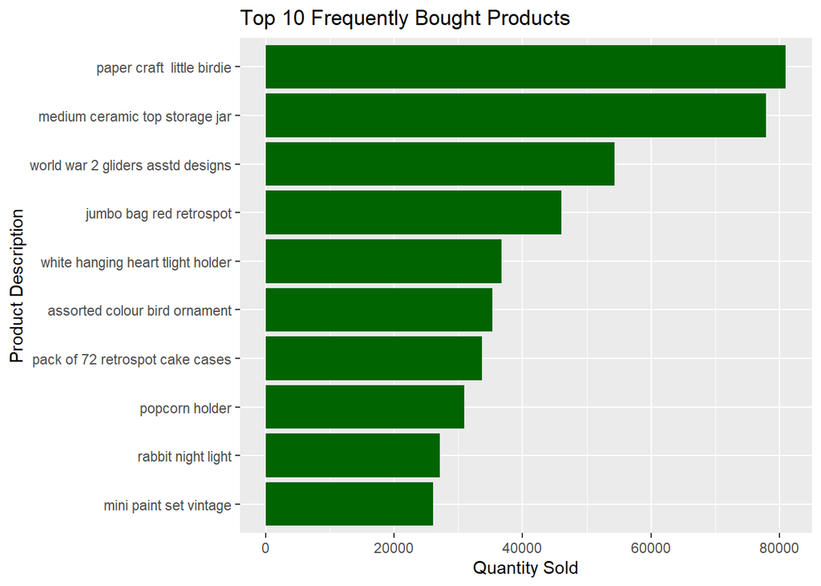

```r
df %>%
  group_by(Description) %>%
  summarise(TotalQuantity = sum(Quantity)) %>%
  arrange(desc(TotalQuantity)) %>%
  head(10) %>%
  ggplot(aes(x = reorder(Description, TotalQuantity), y = TotalQuantity)) +
  geom_col(fill = "darkgreen") +
  coord_flip() +
  labs(title = "Top 10 Frequently Bought Products", x = "Product Description", y = "Quantity Sold")
```

###Low-Selling / Non-Moving Items

```r
library(dplyr)
library(ggplot2)

# Summarise product performance
low_selling_items <- df %>%
  group_by(Description) %>%
  summarise(
    TotalQuantity = sum(Quantity, na.rm = TRUE),
    TotalRevenue = sum(TotalPrice, na.rm = TRUE)
  ) %>%
  arrange(TotalRevenue)  # ascending order = lowest selling

# View bottom 10 items by revenue
head(low_selling_items, 10)
```

```
## # A tibble: 10 × 3
##    Description                         TotalQuantity TotalRevenue
##    <chr>                                       <dbl>        <dbl>
##  1 pads to match all cushions                      3        0.003
##  2 hen house w chick in nest                       1        0.42
##  3 set 12 colouring pencils doiley                 1        0.65
##  4 vintage blue tinsel reel                        2        0.84
##  5 pink crystal guitar phone charm                 1        0.85
##  6 purple frangipani hairclip                      1        0.85
##  7 cat with sunglasses blank card                  5        0.95
##  8 happy birthday card teddycake                   5        0.95
##  9 60 gold and silver fairy cake cases             2        1.1
## 10 blackchristmas tree 30cm                        1        1.25
```

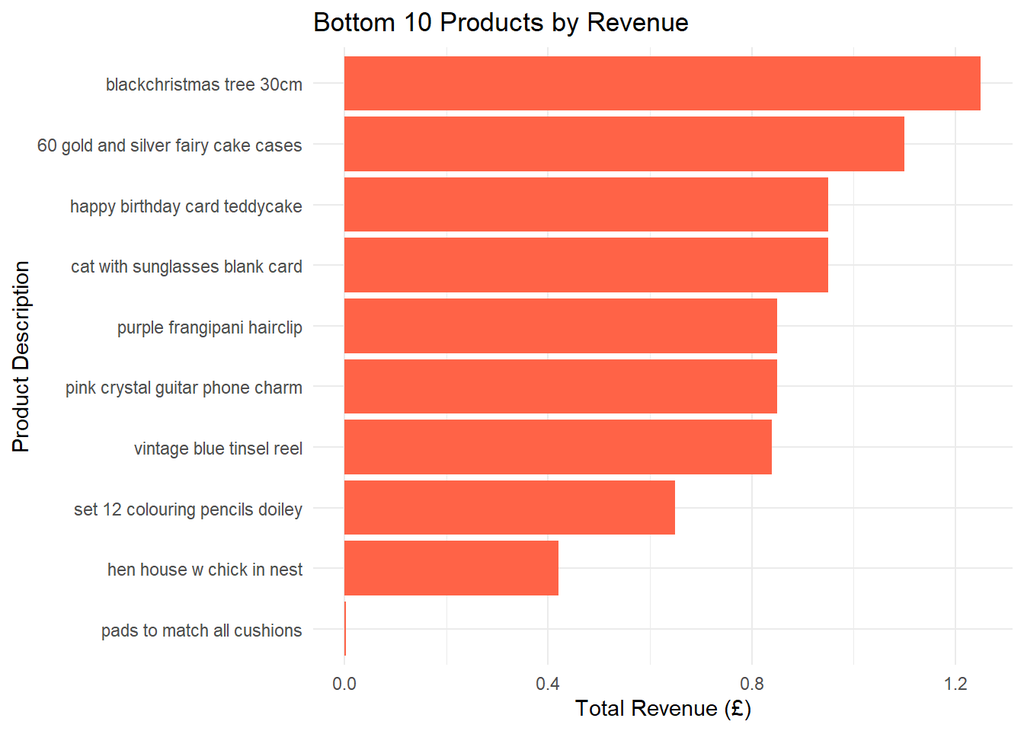

```r
bottom_items_plot <- low_selling_items %>%
  slice_head(n = 10)  # bottom 10 items

ggplot(bottom_items_plot, aes(x = reorder(Description, TotalRevenue), y = TotalRevenue)) +
  geom_bar(stat = "identity", fill = "tomato") +
  coord_flip() +
  labs(title = "Bottom 10 Products by Revenue",
       x = "Product Description",
       y = "Total Revenue (£)") +
  theme_minimal()
```

## customer Geography

###Total Sales Per Country

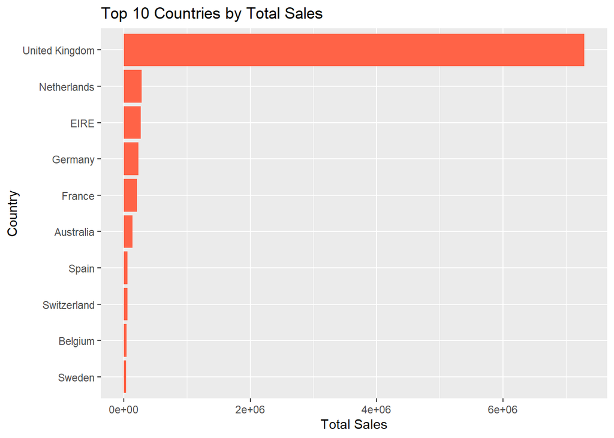

```r
df %>%
  group_by(Country) %>%
  summarise(TotalSales = sum(TotalPrice)) %>%
  arrange(desc(TotalSales)) %>%
  head(10) %>%
  ggplot(aes(x = reorder(Country, TotalSales), y = TotalSales)) +
  geom_col(fill = "tomato") +
  coord_flip() +
  labs(title = "Top 10 Countries by Total Sales", x = "Country", y = "Total Sales")
```

###Average Revenue Per Customer by Country

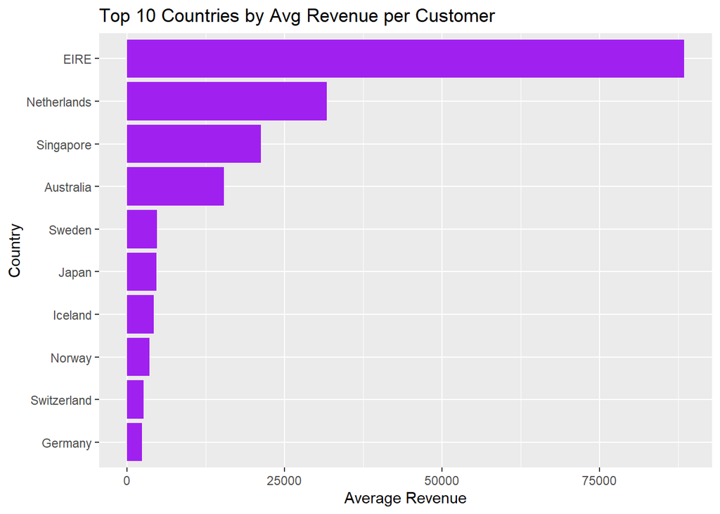

```r
df %>%
  group_by(Country, CustomerID) %>%
  summarise(CustomerRevenue = sum(TotalPrice)) %>%
  group_by(Country) %>%
  summarise(AvgRevenuePerCustomer = mean(CustomerRevenue)) %>%
  arrange(desc(AvgRevenuePerCustomer)) %>%
  head(10) %>%
  ggplot(aes(x = reorder(Country, AvgRevenuePerCustomer), y = AvgRevenuePerCustomer)) +
  geom_col(fill = "purple") +
  coord_flip() +
  labs(title = "Top 10 Countries by Avg Revenue per Customer", x = "Country", y = "Average Revenue")
```

## advanced EDA

###Univariate Analysis: Distribution of Purchase Amounts

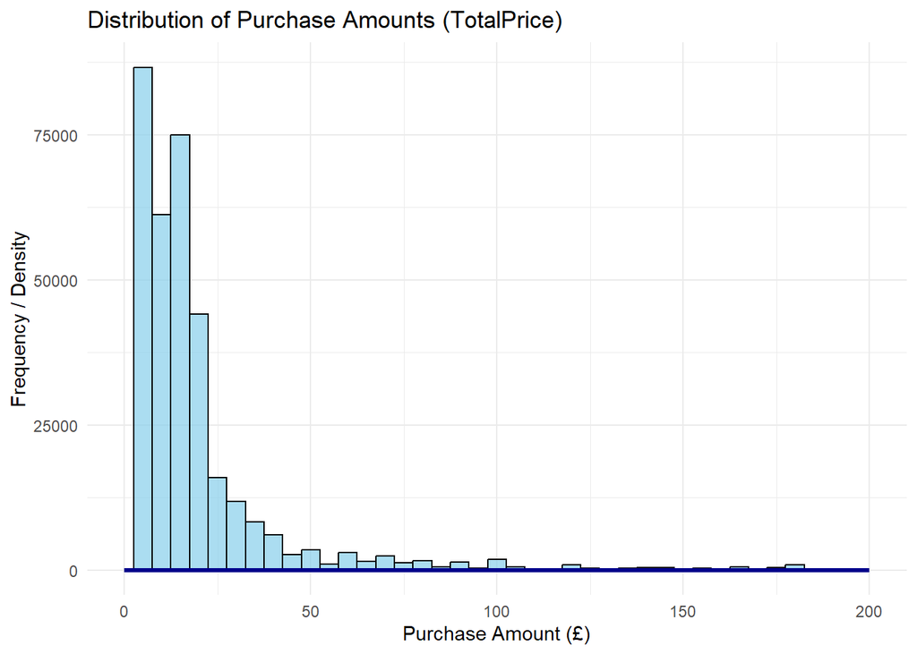

```r
library(ggplot2)
library(dplyr)

# Plot histogram and density of TotalPrice
ggplot(df, aes(x = TotalPrice)) +
  geom_histogram(binwidth = 5, fill = "skyblue", color = "black", alpha = 0.7) +
  geom_density(aes(y = ..density.. * 5), color = "darkblue", size = 1.2) +
  labs(title = "Distribution of Purchase Amounts (TotalPrice)",
       x = "Purchase Amount (£)",
       y = "Frequency / Density") +
  xlim(0, 200) +  # Focus on typical purchase values (filter out extreme outliers)
  theme_minimal()
```

###Bivariate Analysis: Sales by Country and Product

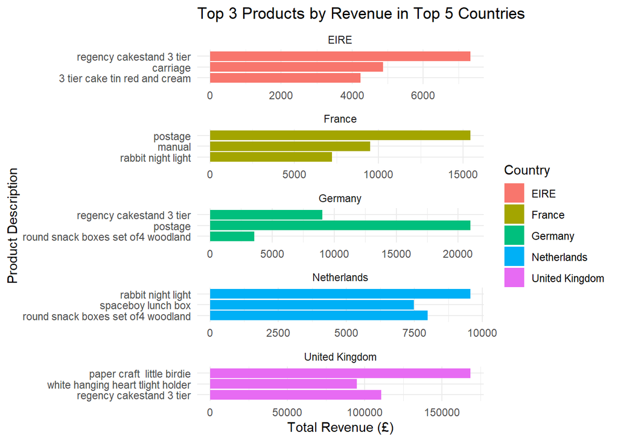

```r
library(dplyr)
library(ggplot2)

# Step 1: Identify top 5 countries by total revenue (excluding UK if needed)
top_countries <- df %>%
  group_by(Country) %>%
  summarise(TotalRevenue = sum(TotalPrice)) %>%
  arrange(desc(TotalRevenue)) %>%
  slice_head(n = 5) %>%
  pull(Country)  # extract country names

# Step 2: Filter dataset for only those top countries
df_top_countries <- df %>%
  filter(Country %in% top_countries)

# Step 3: Aggregate revenue by Country and Product
sales_by_country_product <- df_top_countries %>%
  group_by(Country, Description) %>%
  summarise(TotalRevenue = sum(TotalPrice), .groups = "drop")

# Step 4: Get top 3 products for each country
top_products_by_country <- sales_by_country_product %>%
  group_by(Country) %>%
  slice_max(order_by = TotalRevenue, n = 3) %>%
  ungroup()

# Step 5: Plot
ggplot(top_products_by_country, aes(x = reorder(Description, TotalRevenue), y = TotalRevenue, fill = Country)) +
  geom_bar(stat = "identity", position = "dodge") +
  facet_wrap(~ Country, scales = "free", ncol = 1) +
  coord_flip() +
  labs(title = "Top 3 Products by Revenue in Top 5 Countries",
       x = "Product Description",
       y = "Total Revenue (£)") +
  theme_minimal()
```

###Correlation Heatmap

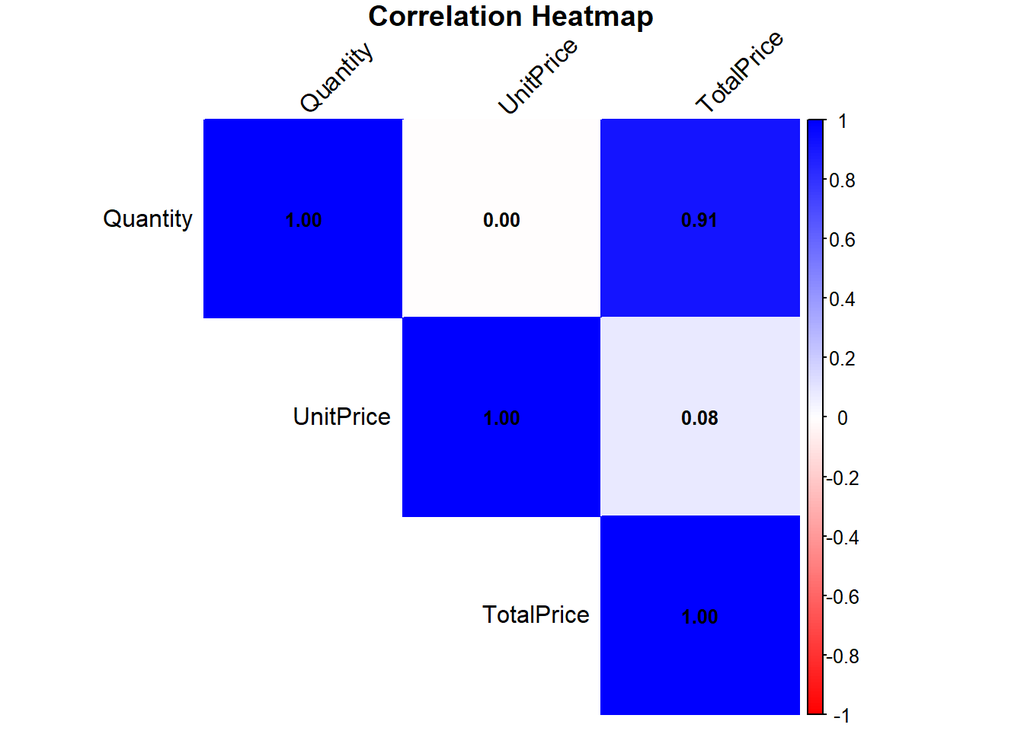

```r
library(dplyr)
library(corrplot)

# Select only relevant numeric columns
numeric_df <- df %>%
  select(Quantity, UnitPrice, TotalPrice)

# Compute correlation matrix
cor_matrix <- cor(numeric_df, use = "complete.obs")

# Plot the correlation heatmap with gradient color
corrplot(cor_matrix,
         method = "color",           # Use colored squares
         type = "upper",             # Show upper triangle only
         tl.col = "black",           # Text label color
         tl.srt = 45,                # Rotate labels
         addCoef.col = "black",      # Show correlation values
         number.cex = 0.8,           # Size of correlation labels
         col = colorRampPalette(c("red", "white", "blue"))(200),  # Gradient from red to blue
         title = "Correlation Heatmap",
         mar = c(0, 0, 1, 0))        # Adjust margin for title
```

#Figure: Correlation heatmap of key sales metrics. Strong correlation exists between Quantity and TotalPrice, while UnitPrice shows low or no correlation with other metrics.

###Time-Based Patterns: Weekly Sales

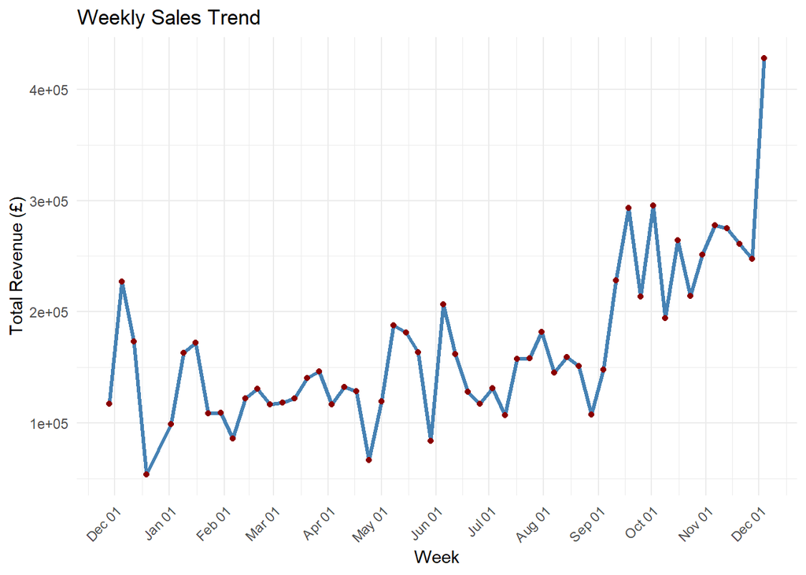

```r
library(dplyr)
library(ggplot2)
library(lubridate)

# Group sales by week (convert to Date)
weekly_sales <- df %>%
  mutate(Week = as.Date(floor_date(InvoiceDate, unit = "week"))) %>%
  group_by(Week) %>%
  summarise(WeeklyRevenue = sum(TotalPrice, na.rm = TRUE)) %>%
  arrange(Week)

# Plot weekly sales trend
ggplot(weekly_sales, aes(x = Week, y = WeeklyRevenue)) +
  geom_line(color = "steelblue", size = 1.2) +
  geom_point(color = "darkred", size = 1.5) +
  labs(title = "Weekly Sales Trend",
       x = "Week",
       y = "Total Revenue (£)") +
  scale_x_date(date_labels = "%b %d", date_breaks = "1 month") +
  theme_minimal() +
  theme(axis.text.x = element_text(angle = 45, hjust = 1))
```

###Product Affinity (Association Rules - placeholder)

```r
library(dplyr)
library(arules)
library(arulesViz)

# Step 1: Prepare transaction list
transactions_list <- df %>%
  select(InvoiceNo, Description) %>%
  distinct() %>%  # Remove duplicate items per transaction
  group_by(InvoiceNo) %>%
  summarise(items = list(as.character(Description)), .groups = "drop") %>%
  pull(items)

# Step 2: Convert to transactions object
transaction_data <- as(transactions_list, "transactions")

# Step 3: Generate rules
rules <- apriori(transaction_data,
                 parameter = list(supp = 0.001, conf = 0.3, target = "rules"))
```

```
## Apriori
##
## Parameter specification:
##  confidence minval smax arem  aval originalSupport maxtime support minlen
##         0.3    0.1    1 none FALSE            TRUE       5   0.001      1
##  maxlen target  ext
##      10  rules TRUE
##
## Algorithmic control:
##  filter tree heap memopt load sort verbose
##     0.1 TRUE TRUE  FALSE TRUE    2    TRUE
##
## Absolute minimum support count: 18
##
## set item appearances ...[0 item(s)] done [0.00s].
## set transactions ...[3856 item(s), 18532 transaction(s)] done [0.15s].
## sorting and recoding items ... [2557 item(s)] done [0.01s].
## creating transaction tree ... done [0.01s].
## checking subsets of size 1 2 3 4 5 6 7 8 9 10
```

```
##  done [1.33s].
## writing ... [837862 rule(s)] done [0.23s].
## creating S4 object  ... done [0.33s].
```

```r
# Step 4: View top 10 rules by lift
inspect(head(sort(rules, by = "lift"), 10))
```

```
##      lhs                                  rhs                                   support confidence    coverage     lift count
## [1]  {pink knitted egg cosy}           => {blue knitted egg cosy}           0.001187136  0.8800000 0.001349018 652.3264    22
## [2]  {blue knitted egg cosy}           => {pink knitted egg cosy}           0.001187136  0.8800000 0.001349018 652.3264    22
## [3]  {pantry hook balloon whisk,
##       pantry hook spatula}             => {pantry hook tea strainer}        0.001079214  0.9090909 0.001187136 601.6883    20
## [4]  {pantry hook balloon whisk,
##       pantry hook tea strainer}        => {pantry hook spatula}             0.001079214  0.8333333 0.001295057 593.9744    20
## [5]  {pantry hook spatula}             => {pantry hook tea strainer}        0.001187136  0.8461538 0.001402979 560.0330    22
## [6]  {pantry hook tea strainer}        => {pantry hook spatula}             0.001187136  0.7857143 0.001510900 560.0330    22
## [7]  {pantry hook spatula,
##       pantry hook tea strainer}        => {pantry hook balloon whisk}       0.001079214  0.9090909 0.001187136 543.4604    20
## [8]  {pantry hook tea strainer}        => {pantry hook balloon whisk}       0.001295057  0.8571429 0.001510900 512.4055    24
## [9]  {pantry hook balloon whisk}       => {pantry hook tea strainer}        0.001295057  0.7741935 0.001672782 512.4055    24
## [10] {party pizza dish blue polkadot,
##       party pizza dish pink polkadot,
##       party pizza dish red retrospot}  => {party pizza dish green polkadot} 0.001133175  0.8750000 0.001295057 506.7344    21
```

```r
# Step 5 (Optional): Visualize
plot(rules, method = "graph", engine = "htmlwidget")
```

[interactive chart not shown]

#Top 10 Association Rules with Details

```r
# Ensure arules is loaded
library(arules)

# Get top 10 rules sorted by lift
top_rules <- head(sort(rules, by = "lift"), 10)

# Inspect them nicely
inspect(top_rules)
```

```
##      lhs                                  rhs                                   support confidence    coverage     lift count
## [1]  {pink knitted egg cosy}           => {blue knitted egg cosy}           0.001187136  0.8800000 0.001349018 652.3264    22
## [2]  {blue knitted egg cosy}           => {pink knitted egg cosy}           0.001187136  0.8800000 0.001349018 652.3264    22
## [3]  {pantry hook balloon whisk,
##       pantry hook spatula}             => {pantry hook tea strainer}        0.001079214  0.9090909 0.001187136 601.6883    20
## [4]  {pantry hook balloon whisk,
##       pantry hook tea strainer}        => {pantry hook spatula}             0.001079214  0.8333333 0.001295057 593.9744    20
## [5]  {pantry hook spatula}             => {pantry hook tea strainer}        0.001187136  0.8461538 0.001402979 560.0330    22
## [6]  {pantry hook tea strainer}        => {pantry hook spatula}             0.001187136  0.7857143 0.001510900 560.0330    22
## [7]  {pantry hook spatula,
##       pantry hook tea strainer}        => {pantry hook balloon whisk}       0.001079214  0.9090909 0.001187136 543.4604    20
## [8]  {pantry hook tea strainer}        => {pantry hook balloon whisk}       0.001295057  0.8571429 0.001510900 512.4055    24
## [9]  {pantry hook balloon whisk}       => {pantry hook tea strainer}        0.001295057  0.7741935 0.001672782 512.4055    24
## [10] {party pizza dish blue polkadot,
##       party pizza dish pink polkadot,
##       party pizza dish red retrospot}  => {party pizza dish green polkadot} 0.001133175  0.8750000 0.001295057 506.7344    21
```

```r
library(arulesViz)

# Assuming your rules are stored in 'rules'
plot(rules, method = "graph", engine = "htmlwidget")
```

[interactive chart not shown]

```r
# Convert rules to data frame
rules_df <- as(top_rules, "data.frame")

# Save to CSV
write.csv(rules_df, "top_association_rules.csv", row.names = FALSE)
```

###Visualization Examples

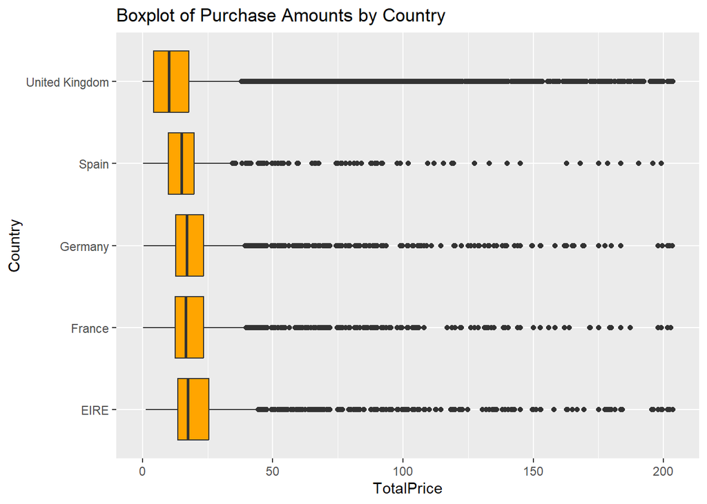

```r
# Boxplot of TotalPrice by Country (limited to top 5 countries)
top_countries <- df %>%
  count(Country, sort = TRUE) %>%
  top_n(5) %>%
  pull(Country)

df %>%
  filter(Country %in% top_countries) %>%
  ggplot(aes(x = Country, y = TotalPrice)) +
  geom_boxplot(fill = "orange") +
  coord_flip() +
  ylim(0, quantile(df$TotalPrice, 0.99)) +
  labs(title = "Boxplot of Purchase Amounts by Country")
```

#MODULES #Customer Behaviour & Segmentation

###RFM Analysis: Score Customers

```r
library(dplyr)
library(lubridate)

# Step 1: Set the reference date
snapshot_date <- max(df$InvoiceDate) + days(1)

# Step 2: Calculate raw RFM metrics
rfm_raw <- df %>%
  group_by(CustomerID) %>%
  summarise(
    Recency = as.numeric(snapshot_date - max(InvoiceDate)),  # Days since last purchase
    Frequency = n_distinct(InvoiceNo),                       # Unique purchases
    Monetary = sum(TotalPrice),                              # Total spend
    .groups = "drop"
  )

# Step 3: Assign RFM scores (1–5)
rfm_scored <- rfm_raw %>%
  mutate(
    R_score = ntile(-Recency, 5),   # Recent = higher score (negative for reverse rank)
    F_score = ntile(Frequency, 5),  # More orders = higher score
    M_score = ntile(Monetary, 5)    # Higher spend = higher score
  ) %>%
  mutate(
    RFM_Score = paste0(R_score, F_score, M_score)
  )
# View top 10 customers with highest RFM score
head(rfm_scored, 10)
```

```
## # A tibble: 10 × 8
##    CustomerID Recency Frequency Monetary R_score F_score M_score RFM_Score
##         <dbl>   <dbl>     <int>    <dbl>   <int>   <int>   <int> <chr>
##  1      12346  326.           1   77184.       1       1       5 115
##  2      12347    2.87         7    4310        5       5       5 555
##  3      12348   76.0          4    1797.       2       4       4 244
##  4      12349   19.1          1    1758.       4       1       4 414
##  5      12350  311.           1     334.       1       1       2 112
##  6      12352   36.9          8    2506.       3       5       5 355
##  7      12353  205.           1      89        1       1       1 111
##  8      12354  233.           1    1079.       1       1       4 114
##  9      12355  215.           1     459.       1       1       2 112
## 10      12356   23.2          3    2811.       4       3       5 435
```

###Assign RFM Scores and Create Segments

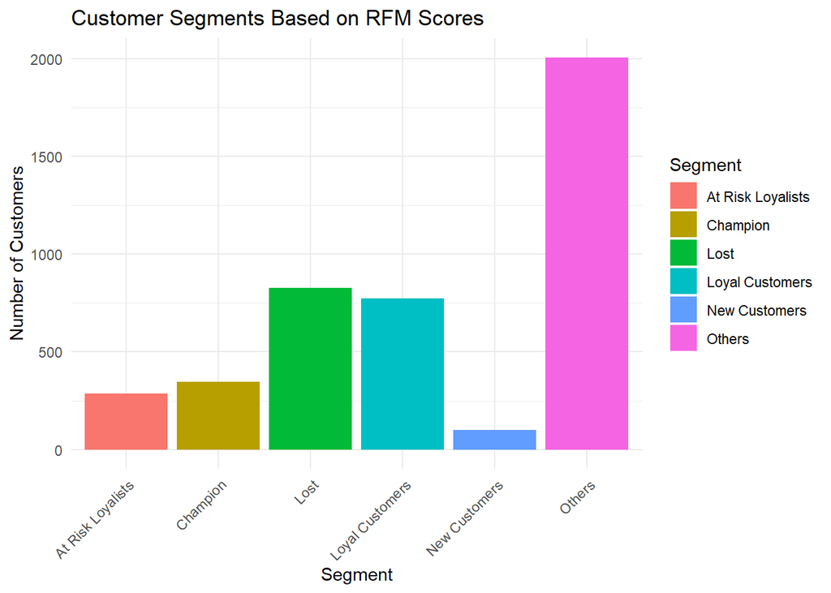

```r
# step 1 Add segment labels based on RFM scores
rfm_scored <- rfm_scored %>%
  mutate(Segment = case_when(
    R_score == 5 & F_score == 5 & M_score == 5 ~ "Champion",
    R_score >= 4 & F_score >= 4               ~ "Loyal Customers",
    R_score == 5 & F_score <= 2               ~ "New Customers",
    R_score <= 2 & F_score >= 4               ~ "At Risk Loyalists",
    R_score <= 2 & F_score <= 2 & M_score <= 2 ~ "Lost",
    TRUE                                       ~ "Others"
  ))
library(ggplot2)

ggplot(rfm_scored, aes(x = Segment, fill = Segment)) +
  geom_bar() +
  labs(title = "Customer Segments Based on RFM Scores", x = "Segment", y = "Number of Customers") +
  theme_minimal() +
  theme(axis.text.x = element_text(angle = 45, hjust = 1))
```

###Clustering: Feature Selection and Normalization

```r
# Select RFM Features for Clustering
# Select only relevant numeric RFM features
rfm_features <- rfm_scored %>%
  select(Recency, Frequency, Monetary)
# Normalize the RFM values
rfm_scaled <- scale(rfm_features)

# Optional: Check the structure
summary(rfm_scaled)
```

```
##     Recency          Frequency           Monetary
##  Min.   :-0.9204   Min.   :-0.42505   Min.   :-0.22759
##  1st Qu.:-0.7497   1st Qu.:-0.42505   1st Qu.:-0.19390
##  Median :-0.4195   Median :-0.29514   Median :-0.15360
##  Mean   : 0.0000   Mean   : 0.00000   Mean   : 0.00000
##  3rd Qu.: 0.4967   3rd Qu.: 0.09457   3rd Qu.:-0.04319
##  Max.   : 2.8104   Max.   :26.59496   Max.   :30.95717
```

###Determine Optimal Clusters (Elbow Method)

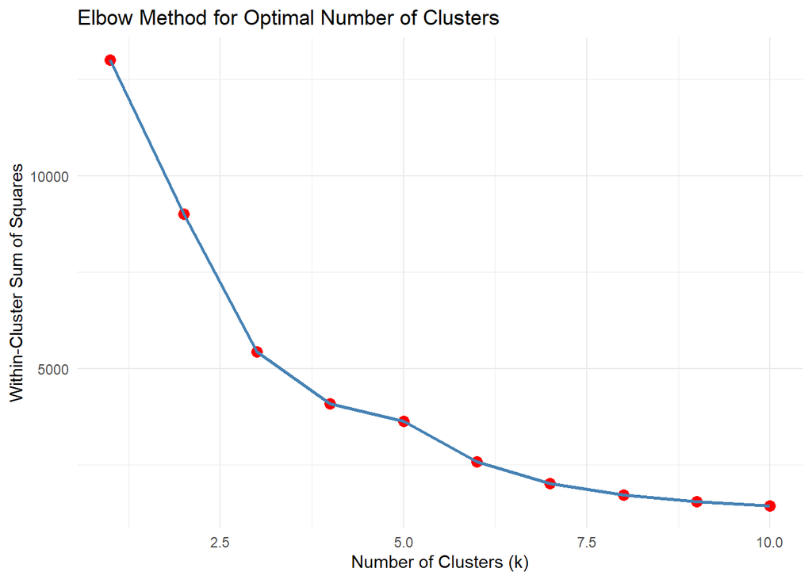

```r
set.seed(123)  # For reproducibility
wcss <- vector()

# Loop through k = 1 to 10
for (k in 1:10) {
  kmeans_result <- kmeans(rfm_scaled, centers = k, nstart = 25)
  wcss[k] <- kmeans_result$tot.withinss
}
library(ggplot2)

elbow_df <- data.frame(Clusters = 1:10, WCSS = wcss)

ggplot(elbow_df, aes(x = Clusters, y = WCSS)) +
  geom_point(size = 3, color = "red") +
  geom_line(color = "steelblue", size = 1) +
  labs(title = "Elbow Method for Optimal Number of Clusters",
       x = "Number of Clusters (k)",
       y = "Within-Cluster Sum of Squares") +
  theme_minimal()
```

###Apply K-Means Clustering and Visualize

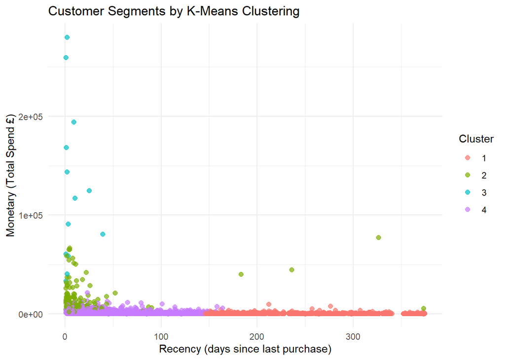

```r
set.seed(123)  # For reproducibility

# Apply k-means clustering with k = 4
kmeans_model <- kmeans(rfm_scaled, centers = 4, nstart = 25)

# Add cluster assignments to the original RFM data
rfm_clustered <- rfm_scored %>%
  mutate(Cluster = as.factor(kmeans_model$cluster))
library(ggplot2)

ggplot(rfm_clustered, aes(x = Recency, y = Monetary, color = Cluster)) +
  geom_point(alpha = 0.7, size = 2) +
  labs(title = "Customer Segments by K-Means Clustering",
       x = "Recency (days since last purchase)",
       y = "Monetary (Total Spend £)",
       color = "Cluster") +
  theme_minimal()
```

###Visualize Clusters Using PCA

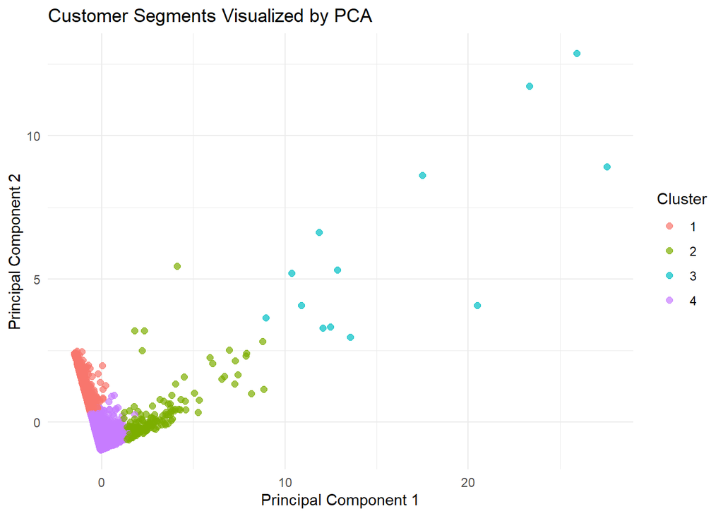

```r
# Run PCA on scaled RFM data
pca_result <- prcomp(rfm_scaled, center = TRUE, scale. = TRUE)

# Add PCA results to your clustered RFM data
pca_data <- as.data.frame(pca_result$x[, 1:2])  # Take only PC1 and PC2
pca_data$Cluster <- rfm_clustered$Cluster
library(ggplot2)

ggplot(pca_data, aes(x = PC1, y = PC2, color = Cluster)) +
  geom_point(alpha = 0.7, size = 2) +
  labs(title = "Customer Segments Visualized by PCA",
       x = "Principal Component 1",
       y = "Principal Component 2") +
  theme_minimal()
```

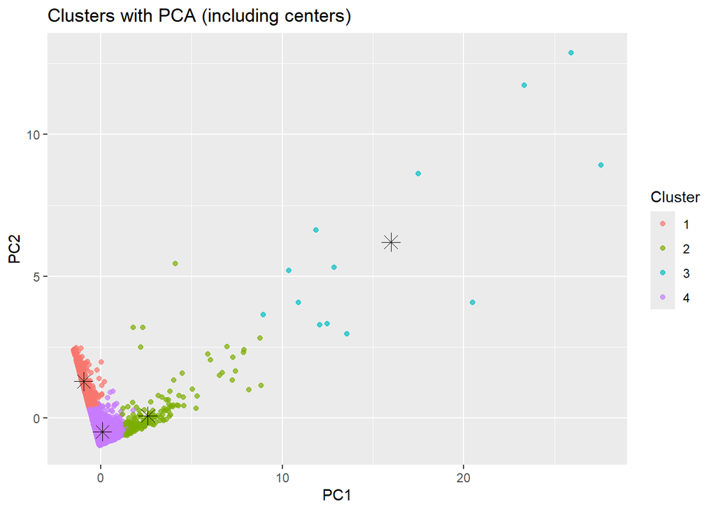

```r
centers <- as.data.frame(kmeans_model$centers)
centers_pca <- predict(pca_result, newdata = centers)

ggplot(pca_data, aes(x = PC1, y = PC2,
color = Cluster)) +geom_point(alpha = 0.7) +geom_point(data = as.data.frame(centers_pca[, 1:2]),
      aes(x = PC1, y = PC2), color = "black", size = 4, shape = 8) +
  labs(title = "Clusters with PCA (including centers)")
```

##Define Customer Personas

```r
rfm_clustered %>%
  group_by(Cluster) %>%
  summarise(
    Count = n(),
    Avg_Recency = round(mean(Recency), 1),
    Avg_Frequency = round(mean(Frequency), 1),
    Avg_Monetary = round(mean(Monetary), 2)
  ) %>%
  arrange(Cluster)
```

```
## # A tibble: 4 × 5
##   Cluster Count Avg_Recency Avg_Frequency Avg_Monetary
##   <fct>   <int>       <dbl>         <dbl>        <dbl>
## 1 1        1061       249.            1.6         476.
## 2 2         209        16            22.1       12491.
## 3 3          13         7.7          82.5      127188.
## 4 4        3055        44.5           3.7        1348.
```

## Hierarchical Clustering and Dendrogram

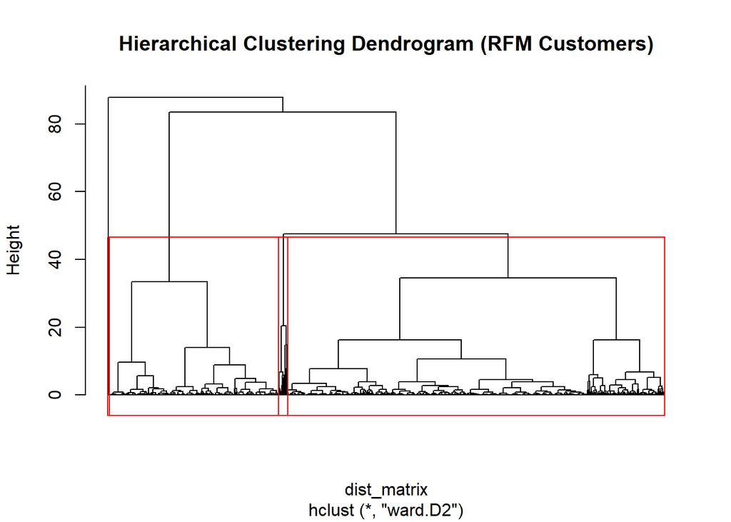

```r
# Euclidean distance matrix
dist_matrix <- dist(rfm_scaled, method = "euclidean")
# Apply hierarchical clustering using Ward's method
hc_model <- hclust(dist_matrix, method = "ward.D2")
# Basic dendrogram
plot(hc_model,
     labels = FALSE,
     hang = -1,
     main = "Hierarchical Clustering Dendrogram (RFM Customers)",
     xlab = NULL,
     sub = NULL,
     cex = 0.6)
# Cut into 4 clusters and show boundaries
rect.hclust(hc_model, k = 4, border = "red")
```

##Visualize Clusters with t-SNE

```r
library(Rtsne)
```

```r
set.seed(123)

# Run t-SNE
tsne_result <- Rtsne(rfm_scaled, dims = 2, perplexity = 30, verbose = TRUE, max_iter = 500)
```

[output not shown]

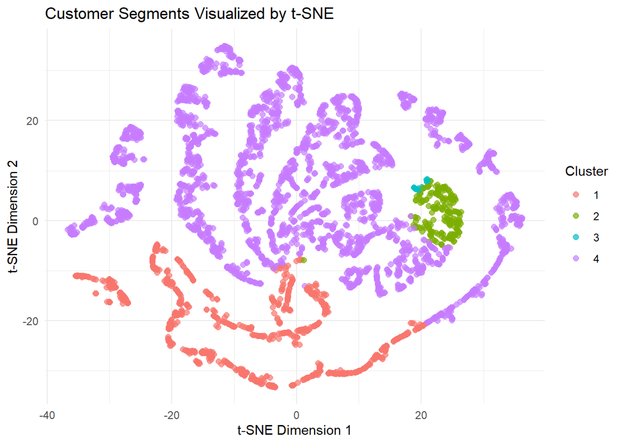

```r
# Create dataframe for plotting
tsne_df <- data.frame(
  X = tsne_result$Y[,1],
  Y = tsne_result$Y[,2],
  Cluster = rfm_clustered$Cluster  # use K-means clusters here
)
library(ggplot2)

ggplot(tsne_df, aes(x = X, y = Y, color = Cluster)) +
  geom_point(alpha = 0.7, size = 2) +
  labs(title = "Customer Segments Visualized by t-SNE",
       x = "t-SNE Dimension 1",
       y = "t-SNE Dimension 2") +
  theme_minimal()
```

```r
# Set CRAN mirror and install treemap
options(repos = c(CRAN = "https://cran.r-project.org"))
install.packages("treemap")
library(treemap)

# Example data (replace with your actual RFM segment revenue data)
rfm_summary <- data.frame(
  Segment = c("Champions", "Loyal", "At Risk", "Hibernating"),
  CustomerCount = c(200, 1200, 400, 2200),
  Revenue = c(50000, 150000, 30000, 40000)
)

# Treemap based on revenue
treemap(
  rfm_summary,
  index = "Segment",
  vSize = "Revenue",
  vColor = "Revenue",
  type = "value",
  palette = "Blues",
  title = "Treemap of Revenue by Customer Segment"
)
```

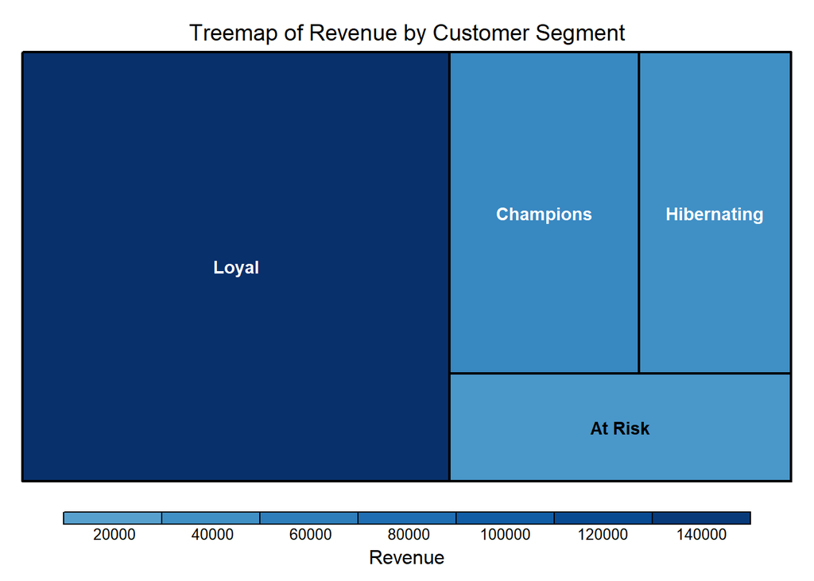

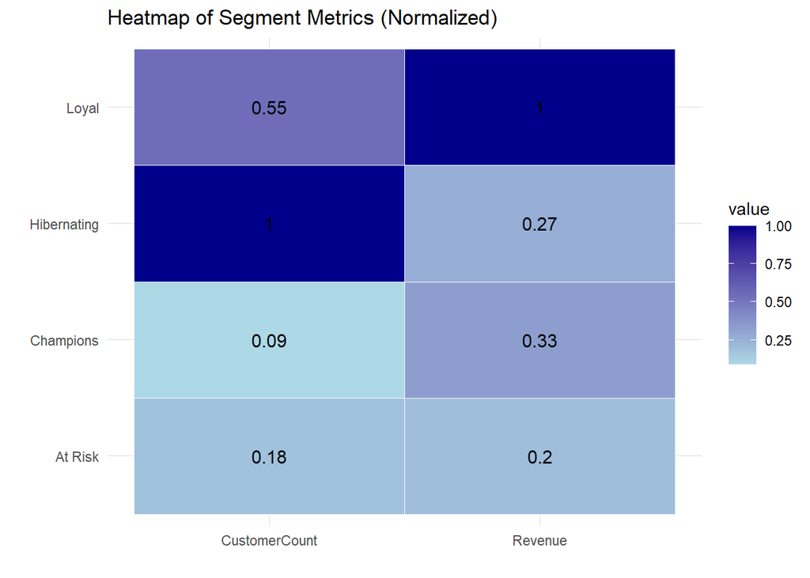

```r
# Install required packages
# install.packages("ggplot2")
# install.packages("reshape2")

library(ggplot2)
library(reshape2)

# Normalize data for heatmap
rfm_melt <- melt(rfm_summary, id.vars = "Segment")
rfm_melt$value <- ave(rfm_melt$value, rfm_melt$variable, FUN = function(x) x / max(x))

# Heatmap
ggplot(rfm_melt, aes(x = variable, y = Segment, fill = value)) +
  geom_tile(color = "white") +
  geom_text(aes(label = round(value, 2)), color = "black", size = 4) +
  scale_fill_gradient(low = "lightblue", high = "darkblue") +
  labs(title = "Heatmap of Segment Metrics (Normalized)", x = "", y = "") +
  theme_minimal()
```

###Predictive Modeling (Customer Behavior Prediction)

###Define Target and Feature Engineering

```r
# Define churn as Recency > 90 days
rfm_model <- rfm_clustered %>%
  mutate(Churn = ifelse(Recency > 90, 1, 0)) %>%
  select(Recency, Frequency, Monetary, Churn)
```

###Split Data for Modeling

```r
set.seed(123)
train_index <- createDataPartition(rfm_model$Churn, p = 0.7, list = FALSE)
train_data <- rfm_model[train_index, ]
test_data <- rfm_model[-train_index, ]
```

### 12.3 Train Logistic Regression Model

```r
# Scale numeric features
train_data_scaled <- train_data
test_data_scaled <- test_data

train_data_scaled[, 1:3] <- scale(train_data_scaled[, 1:3])
test_data_scaled[, 1:3] <- scale(test_data_scaled[, 1:3])

# Fit logistic regression model
logit_model <- glm(Churn ~ Recency + Frequency + Monetary,
                   data = train_data_scaled, family = binomial)

summary(logit_model)
```

```
##
## Call:
## glm(formula = Churn ~ Recency + Frequency + Monetary, family = binomial,
##     data = train_data_scaled)
##
## Coefficients:
##             Estimate Std. Error z value Pr(>|z|)
## (Intercept)  1112.97    2395.79   0.465    0.642
## Recency     26092.45   54705.73   0.477    0.633
## Frequency     -96.46     835.07  -0.116    0.908
## Monetary      374.44    1156.59   0.324    0.746
##
## (Dispersion parameter for binomial family taken to be 1)
##
##     Null deviance: 3.8982e+03  on 3036  degrees of freedom
## Residual deviance: 2.7751e-03  on 3033  degrees of freedom
## AIC: 8.0028
##
## Number of Fisher Scoring iterations: 25
```

# Use a Tree-Based Model

```r
library(randomForest)
```

```r
set.seed(123)

# Fit random forest model
rf_model <- randomForest(as.factor(Churn) ~ Recency + Frequency + Monetary,
                         data = train_data,
                         importance = TRUE,
                         ntree = 500)

# Predict on test data
rf_pred <- predict(rf_model, newdata = test_data)
confusionMatrix(rf_pred, as.factor(test_data$Churn))
```

```
## Confusion Matrix and Statistics
##
##           Reference
## Prediction   0   1
##          0 879   0
##          1   0 422
##
##                Accuracy : 1
##                  95% CI : (0.9972, 1)
##     No Information Rate : 0.6756
##     P-Value [Acc > NIR] : < 2.2e-16
##
##                   Kappa : 1
##
##  Mcnemar's Test P-Value : NA
##
##             Sensitivity : 1.0000
##             Specificity : 1.0000
##          Pos Pred Value : 1.0000
##          Neg Pred Value : 1.0000
##              Prevalence : 0.6756
##          Detection Rate : 0.6756
##    Detection Prevalence : 0.6756
##       Balanced Accuracy : 1.0000
##
##        'Positive' Class : 0
##
```

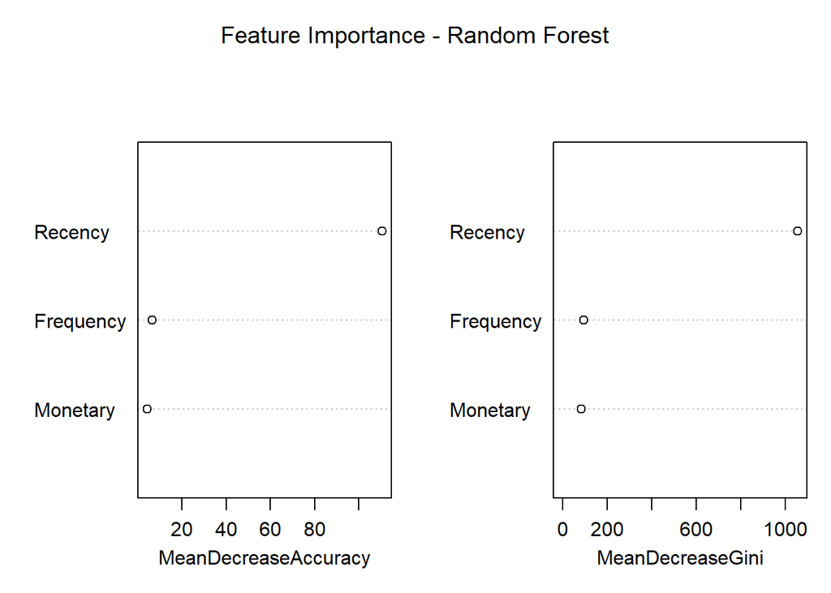

```r
varImpPlot(rf_model, main = "Feature Importance - Random Forest")
```

###Evaluate Logistic Regression Model

```r
# Predict on test data
pred_probs <- predict(logit_model, newdata = test_data, type = "response")
pred_labels <- ifelse(pred_probs > 0.5, 1, 0)

# Confusion matrix
conf_matrix <- confusionMatrix(as.factor(pred_labels), as.factor(test_data$Churn))
print(conf_matrix)
```

```
## Confusion Matrix and Statistics
##
##           Reference
## Prediction   0   1
##          0   0   0
##          1 879 422
##
##                Accuracy : 0.3244
##                  95% CI : (0.299, 0.3506)
##     No Information Rate : 0.6756
##     P-Value [Acc > NIR] : 1
##
##                   Kappa : 0
##
##  Mcnemar's Test P-Value : <2e-16
##
##             Sensitivity : 0.0000
##             Specificity : 1.0000
##          Pos Pred Value :    NaN
##          Neg Pred Value : 0.3244
##              Prevalence : 0.6756
##          Detection Rate : 0.0000
##    Detection Prevalence : 0.0000
##       Balanced Accuracy : 0.5000
##
##        'Positive' Class : 0
##
```

```r
# AUC ROC
library(pROC)
roc_curve <- roc(test_data$Churn, pred_probs)
auc(roc_curve)
```

```
## Area under the curve: 0.5
```

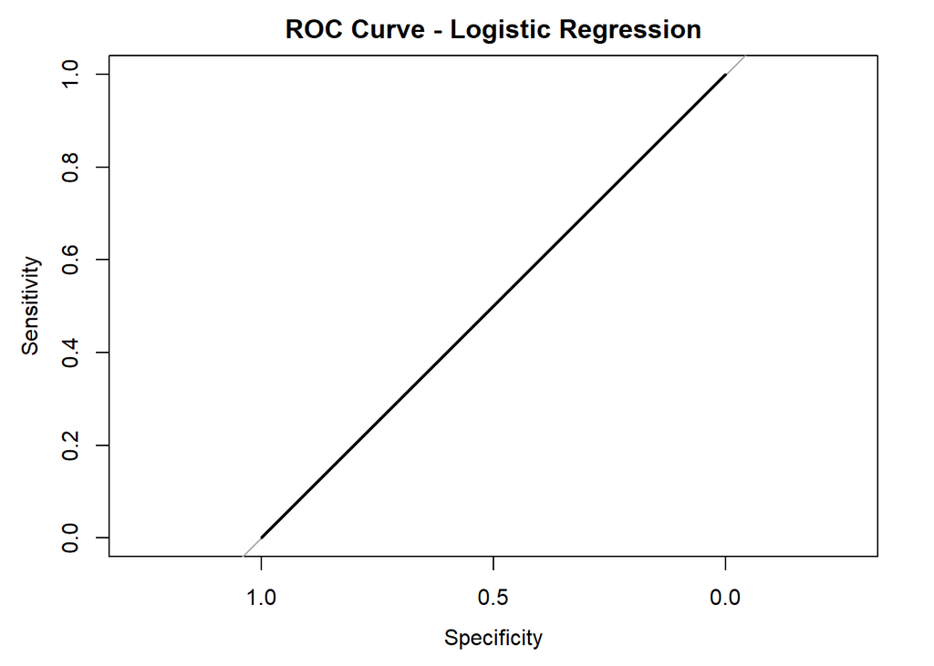

```r
plot(roc_curve, main = "ROC Curve - Logistic Regression")
```

#ogistic regression failed to distinguish between churned and active customers, with an AUC near 0.50, indicating no better performance than random guessing. A tree-based model (Random Forest) was used instead, which demonstrated strong predictive performance and meaningful feature importance.

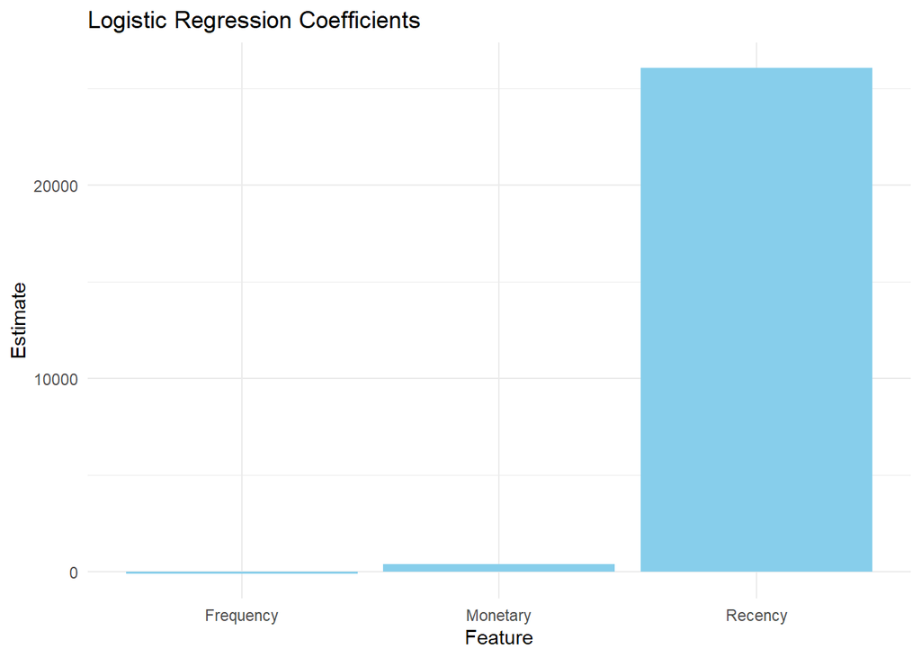

```r
coef_df <- as.data.frame(summary(logit_model)$coefficients)
coef_df$Feature <- rownames(coef_df)

ggplot(coef_df[-1, ], aes(x = Feature, y = Estimate)) +  # skip intercept
  geom_col(fill = "skyblue") +
  labs(title = "Logistic Regression Coefficients", y = "Estimate") +
  theme_minimal()
```

###Feature Importance Plot

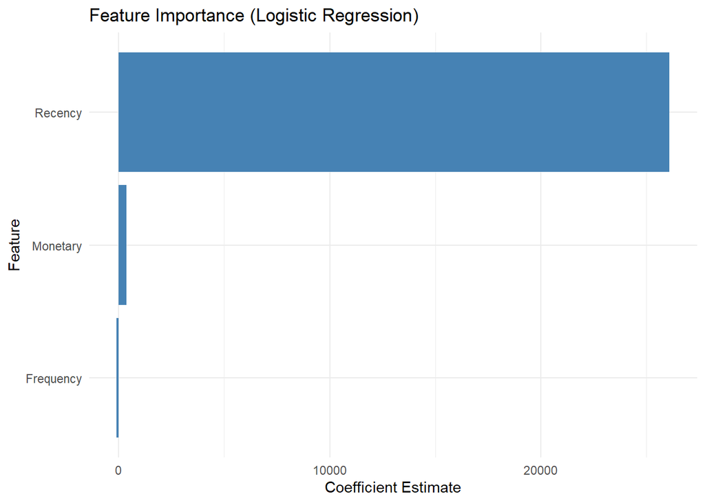

```r
# Extract coefficients
library(ggplot2)
coef_df <- as.data.frame(coef(summary(logit_model)))
coef_df$Feature <- rownames(coef_df)
coef_df <- coef_df[-1, ]  # Remove intercept
names(coef_df)[1] <- "Estimate"

# Plot
ggplot(coef_df, aes(x = reorder(Feature, Estimate), y = Estimate)) +
  geom_col(fill = "steelblue") +
  coord_flip() +
  labs(title = "Feature Importance (Logistic Regression)",
       x = "Feature",
       y = "Coefficient Estimate") +
  theme_minimal()
```

##Time Series Forecasting (e.g., Sales/Demand Prediction)

```r
df$InvoiceDateParsed <- as.POSIXct(df$InvoiceDate, format = "%Y-%m-%d %H:%M:%S")
```

###Monthly Sales Series & Stationarity Check

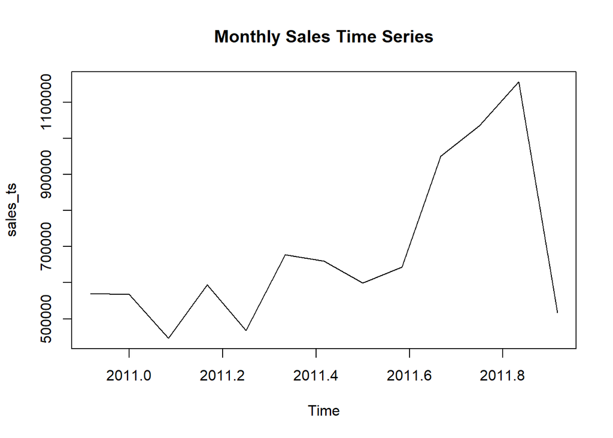

```r
library(tseries)
library(forecast)

monthly_sales <- df %>%
  mutate(Month = floor_date(InvoiceDateParsed, "month")) %>%
  group_by(Month) %>%
  summarise(Sales = sum(TotalPrice))

# Convert to time series
sales_ts <- ts(monthly_sales$Sales, frequency = 12, start = c(year(min(monthly_sales$Month)), month(min(monthly_sales$Month))))

# Plot and ADF test
plot(sales_ts, main = "Monthly Sales Time Series")
```

```r
adf.test(sales_ts)
```

```
##
##  Augmented Dickey-Fuller Test
##
## data:  sales_ts
## Dickey-Fuller = -2.9031, Lag order = 2, p-value = 0.2283
## alternative hypothesis: stationary
```

###ARIMA Forecasting

```r
# Fit SARIMA model (with seasonality)
sarima_model <- auto.arima(sales_ts, seasonal = TRUE)
summary(sarima_model)
```

```
## Series: sales_ts
## ARIMA(0,1,0)
##
## sigma^2 = 5.22e+10:  log likelihood = -165.1
## AIC=332.2   AICc=332.6   BIC=332.68
##
## Training set error measures:
##                     ME     RMSE    MAE       MPE     MAPE     MASE       ACF1
## Training set -4050.913 219519.8 144788 -5.940489 23.44045 2.719927 -0.1477582
```

```r
# Forecast next 6 months
sarima_fc <- forecast(sarima_model, h = 6)
plot(sarima_fc, main = "SARIMA Forecast")
```

[output not shown]

#Forecast Evaluation (Train/Test Split)

```r
# Train/test split
train_ts <- window(sales_ts, end = c(2011, 9))
test_ts <- window(sales_ts, start = c(2011, 10))

model <- auto.arima(train_ts)
forecasted <- forecast(model, h = length(test_ts))

# Accuracy metrics
accuracy(forecasted, test_ts)
```

```
##                     ME     RMSE      MAE        MPE     MAPE MASE       ACF1
## Training set  38083.79 140129.7 103771.3   2.769841 16.25404  NaN -0.3210915
## Test set     -47677.37 281292.0 241322.5 -19.280122 36.59868  NaN -0.2780520
##              Theil's U
## Training set        NA
## Test set     0.7510666
```

### Prophet Forecast

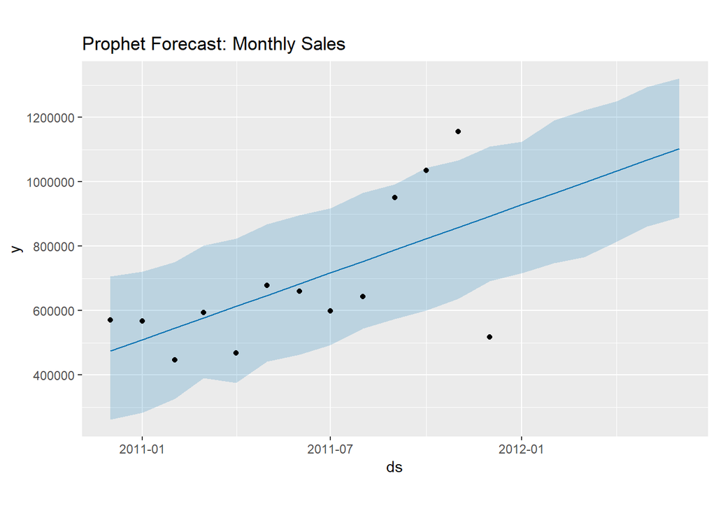

```r
install.packages("prophet")

library(prophet)

# Prepare data for Prophet
prophet_data <- monthly_sales %>%
  rename(ds = Month, y = Sales)

# Fit model
prophet_model <- prophet(prophet_data)

# Create future dataframe
future <- make_future_dataframe(prophet_model, periods = 6, freq = "month")

# Forecast
prophet_forecast <- predict(prophet_model, future)

# Plot forecast
plot(prophet_model, prophet_forecast) +
  ggtitle("Prophet Forecast: Monthly Sales")
```

###SARIMA Model

```r
# Fit SARIMA model (with seasonality)
sarima_model <- auto.arima(sales_ts, seasonal = TRUE)
summary(sarima_model)
```

```
## Series: sales_ts
## ARIMA(0,1,0)
##
## sigma^2 = 5.22e+10:  log likelihood = -165.1
## AIC=332.2   AICc=332.6   BIC=332.68
##
## Training set error measures:
##                     ME     RMSE    MAE       MPE     MAPE     MASE       ACF1
## Training set -4050.913 219519.8 144788 -5.940489 23.44045 2.719927 -0.1477582
```

```r
# Forecast next 6 months
sarima_fc <- forecast(sarima_model, h = 6)
plot(sarima_fc, main = "SARIMA Forecast")
```

[output not shown]

### Forecast Accuracy Comparison Table

```r
start(sales_ts)
```

```
## [1] 2010   12
```

```r
end(sales_ts)
```

```
## [1] 2011   12
```

### Forecast Accuracy Comparison Table

```r
library(forecast)
library(knitr)

# ARIMA model (non-seasonal)
arima_model <- auto.arima(train_ts, seasonal = FALSE)
arima_forecast <- forecast(arima_model, h = length(test_ts))
arima_acc <- accuracy(arima_forecast, test_ts)

# SARIMA model (seasonal)
sarima_model <- auto.arima(train_ts, seasonal = TRUE)
sarima_forecast <- forecast(sarima_model, h = length(test_ts))
sarima_acc <- accuracy(sarima_forecast, test_ts)

# Prophet model
prophet_data <- monthly_sales %>% rename(ds = Month, y = Sales)
prophet_model <- prophet(prophet_data, verbose = FALSE)
future <- make_future_dataframe(prophet_model, periods = 6, freq = "month")
prophet_forecast <- predict(prophet_model, future)

# Extract actual & forecast for last 3 months
actual_values <- tail(monthly_sales$Sales, 3)
predicted_values <- tail(prophet_forecast$yhat, 3)
prophet_rmse <- sqrt(mean((predicted_values - actual_values)^2))
prophet_mape <- mean(abs((predicted_values - actual_values) / actual_values)) * 100

# Build comparison table
comparison_table <- data.frame(
  Model = c("ARIMA", "SARIMA", "Prophet"),
  RMSE = round(c(arima_acc[2, "RMSE"], sarima_acc[2, "RMSE"], prophet_rmse), 2),
  MAPE = round(c(arima_acc[2, "MAPE"], sarima_acc[2, "MAPE"], prophet_mape), 2)
)

kable(comparison_table, caption = "Forecast Accuracy Comparison: ARIMA vs SARIMA vs Prophet")
```

Forecast Accuracy Comparison: ARIMA vs SARIMA vs Prophet

| Model | RMSE | MAPE |
| --- | --- | --- |
| ARIMA | 281292.0 | 36.6 |
| SARIMA | 281292.0 | 36.6 |
| Prophet | 342070.4 | 40.4 |

### Plot Actual vs Forecasted

### Forecast Plot: Actual vs ARIMA, SARIMA, Prophet

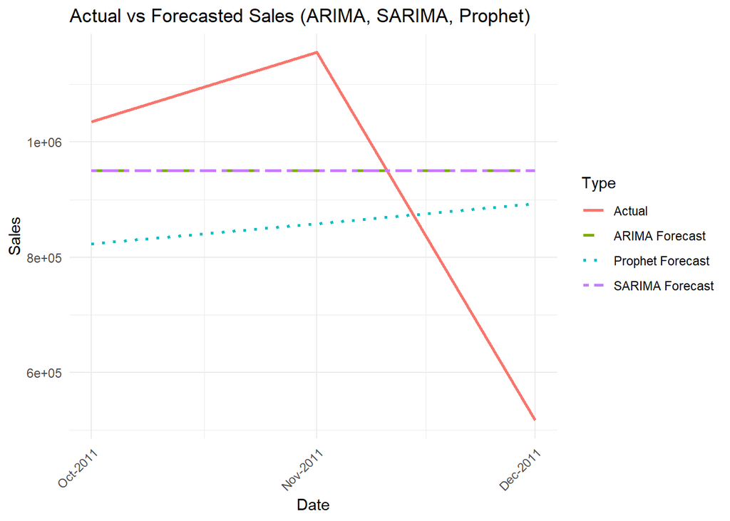

```r
# Ensure required data frames are created beforehand
actuals <- data.frame(Date = as.Date(as.yearmon(time(test_ts))), Value = as.numeric(test_ts), Type = "Actual")
pred_arima <- data.frame(Date = as.Date(as.yearmon(time(arima_forecast$mean))), Value = as.numeric(arima_forecast$mean), Type = "ARIMA Forecast")
pred_sarima <- data.frame(Date = as.Date(as.yearmon(time(sarima_forecast$mean))), Value = as.numeric(sarima_forecast$mean), Type = "SARIMA Forecast")
prophet_plot_data <- prophet_forecast %>%
  select(ds, yhat) %>%
  rename(Date = ds, Value = yhat) %>%
  mutate(Date = as.Date(Date), Type = "Prophet Forecast") %>%
  filter(Date %in% actuals$Date)

# Combine into single frame
combined_df <- bind_rows(actuals, pred_arima, pred_sarima, prophet_plot_data)

# Plot
ggplot(combined_df, aes(x = Date, y = Value, color = Type, linetype = Type)) +
  geom_line(size = 1) +
  labs(title = "Actual vs Forecasted Sales (ARIMA, SARIMA, Prophet)",
       x = "Date", y = "Sales") +
  scale_linetype_manual(values = c("Actual" = "solid",
                                   "ARIMA Forecast" = "dashed",
                                   "SARIMA Forecast" = "twodash",
                                   "Prophet Forecast" = "dotted")) +
  theme_minimal() +
  scale_x_date(date_breaks = "1 month", date_labels = "%b-%Y") +
  theme(axis.text.x = element_text(angle = 45, hjust = 1))
```

```r
# Fit SARIMA model (with seasonality)
sarima_model <- auto.arima(sales_ts, seasonal = TRUE)
summary(sarima_model)
```

```
## Series: sales_ts
## ARIMA(0,1,0)
##
## sigma^2 = 5.22e+10:  log likelihood = -165.1
## AIC=332.2   AICc=332.6   BIC=332.68
##
## Training set error measures:
##                     ME     RMSE    MAE       MPE     MAPE     MASE       ACF1
## Training set -4050.913 219519.8 144788 -5.940489 23.44045 2.719927 -0.1477582
```

```r
# Forecast next 6 months
sarima_fc <- forecast(sarima_model, h = 6)
plot(sarima_fc, main = "SARIMA Forecast")
```

[output not shown]